# Module6_v3

### Grading

The final score that you will receive for your programming assignment is generated in relation to the total points set in your programming assignment item—not the total point value in the nbgrader notebook.

When calculating the final score shown to learners, the programming assignment takes the percentage of earned points vs. the total points provided by nbgrader and returns a score matching the equivalent percentage of the point value for the programming assignment.

**DO NOT CHANGE VARIABLE OR METHOD SIGNATURES.** The autograder will not work properly if your change the variable or method signatures.

### WARNING

Please refrain from using **print statements/anything that dumps large outputs(>500 lines) to STDOUT** to avoid running to into **memory issues**. Doing so requires your entire lab to be reset which may also result in loss of progress and you will be required to reach out to Coursera for assistance with this. This process usually takes time causing delays to your submission.

### Validate Button

Please note that this assignment uses nbgrader to facilitate grading. You will see a **validate button** at the top of your Jupyter notebook. If you hit this button, it will run tests cases for the lab that aren't hidden. It is good to use the validate button before submitting the lab. Do know that the labs in the course contain hidden test cases. The validate button will not let you know whether these test cases pass. After submitting your lab, you can see more information about these hidden test cases in the Grader Output.

*Cells with longer execution times will cause the validate button to time out and freeze. Please know that if you run into Validate time-outs, it will not affect the final submission grading.*

# Homework 6: Support Vector Machines

In this assignment we'll explore the details of the Soft-Margin SVM and look at how the choice of tuning parameters affects the learned models. We'll also look at kernel SVMs for non-linearly separable and methods for choosing and visualizing good hyperparameters.

**Note**: Below are some helper functions which are used throughout this notebook. Execute these before continuing. Do not modify.

```python
import numpy as np
from sklearn.datasets import make_blobs
from matplotlib.colors import Normalize
import matplotlib.pyplot as plt
%matplotlib inline

def linear_plot(X, y, w=None, b=None):

    mycolors = {"blue": "steelblue", "red": "#a76c6e", "green": "#6a9373"}
    colors = [mycolors["red"] if yi==1 else mycolors["blue"] for yi in y]

    # Plot data
    fig, ax = plt.subplots(nrows=1, ncols=1, figsize=(8,8))
    ax.scatter(X[:,0], X[:,1], color=colors, s=150, alpha=0.95, zorder=2)

    # Plot boundaries
    lower_left = np.min([np.min(X[:,0]), np.min(X[:,1])])
    upper_right = np.max([np.max(X[:,0]), np.max(X[:,1])])
    gap = .1*(upper_right-lower_left)
    xplot = np.linspace(lower_left-gap, upper_right+gap, 20)
    if w is not None and b is not None:
        ax.plot(xplot, (-b - w[0]*xplot)/w[1], color="gray", lw=2, zorder=1)
        ax.plot(xplot, ( 1 -b - w[0]*xplot)/w[1], color="gray", lw=2, ls="--", zorder=1)
        ax.plot(xplot, (-1 -b - w[0]*xplot)/w[1], color="gray", lw=2, ls="--", zorder=1)


    ax.set_xlim([lower_left-gap, upper_right+gap])
    ax.set_ylim([lower_left-gap, upper_right+gap])

    ax.grid(alpha=0.25)

def part2data():

    np.random.seed(1239)

    X = np.zeros((22,2))
    X[0:10,0]  = 1.5*np.random.rand(10)
    X[0:10,1]  = 1.5*np.random.rand(10)
    X[10:20,0] = 1.5*np.random.rand(10) +  1.75
    X[10:20,1] = 1.5*np.random.rand(10) +  1
    X[20,0] = 1.5
    X[20,1] = 2.25
    X[21,0] = 1.6
    X[21,1] = 0.25

    y = np.ones(22)
    y[10:20] = -1
    y[20] = 1
    y[21] = -1

    return X, y

def part3data(N=100, seed=1235):

    np.random.seed(seed)

    X = np.random.uniform(-1,1,(N,2))
    y = np.array([1 if y-x > 0 else -1 for (x,y) in zip(X[:,0]**2 * np.sin(2*np.pi*X[:,0]), X[:,1])])
    X = X + np.random.normal(0,.1,(N,2))

    return X, y

def nonlinear_plot(X, y, clf=None):

    mycolors = {"blue": "steelblue", "red": "#a76c6e", "green": "#6a9373"}

    fig, ax = plt.subplots(nrows=1, ncols=1, figsize=(10,10))

    colors = [mycolors["red"] if yi==1 else mycolors["blue"] for yi in y]
    ax.scatter(X[:,0],X[:,1], marker='o', color=colors, s=100, alpha=0.5)

    ax.arrow(-1.25,0,2.5,0, head_length=0.05, head_width=0.05, fc="gray", ec="gray", lw=2, alpha=0.25)
    ax.arrow(0,-1.25,0,2.5, head_length=0.05, head_width=0.05, fc="gray", ec="gray", lw=2, alpha=0.25)
    z = np.linspace(0.25,3.5,10)

    ax.set_xlim([-1.50,1.50])
    ax.set_ylim([-1.50,1.50])

    ax.spines['top'].set_visible(False)
    ax.spines['right'].set_visible(False)
    ax.spines['bottom'].set_visible(False)
    ax.spines['left'].set_visible(False)
    plt.xticks([], fontsize=16)
    plt.yticks([], fontsize=16)


    if clf:

        clf.fit(X,y)

        x_min = X[:, 0].min()+.00
        x_max = X[:, 0].max()-.00
        y_min = X[:, 1].min()+.00
        y_max = X[:, 1].max()-.00

        colors = [mycolors["red"] if yi==1 else mycolors["blue"] for yi in y]

        XX, YY = np.mgrid[x_min:x_max:200j, y_min:y_max:200j]
        Z = clf.decision_function(np.c_[XX.ravel(), YY.ravel()])

        # Put the result into a color plot
        Z = Z.reshape(XX.shape)
        plt.contour(XX, YY, Z, colors=[mycolors["blue"], "gray", mycolors["red"]], linestyles=['--', '-', '--'],
                    levels=[-1.0, 0, 1.0], linewidths=[2,2,2], alpha=0.9)


class MidpointNormalize(Normalize):

    def __init__(self, vmin=None, vmax=None, midpoint=None, clip=False):
        self.midpoint = midpoint
        Normalize.__init__(self, vmin, vmax, clip)

    def __call__(self, value, clip=None):
        x, y = [self.vmin, self.midpoint, self.vmax], [0, 0.5, 1]
        return np.ma.masked_array(np.interp(value, x, y))

def plotSearchGrid(grid):

    scores = [x for x in grid.cv_results_["mean_test_score"]]
    scores = np.array(scores).reshape(len(grid.param_grid["C"]), len(grid.param_grid["gamma"]))

    plt.figure(figsize=(10, 8))
    plt.subplots_adjust(left=.2, right=0.95, bottom=0.15, top=0.95)
    plt.imshow(scores, interpolation='nearest', cmap=plt.cm.hot,
               norm=MidpointNormalize(vmin=0.2, midpoint=0.92))
    plt.xlabel('gamma')
    plt.ylabel('C')
    plt.colorbar()
    plt.xticks(np.arange(len(grid.param_grid["gamma"])), grid.param_grid["gamma"], rotation=45)
    plt.yticks(np.arange(len(grid.param_grid["C"])), grid.param_grid["C"])
    plt.title('Validation accuracy')
    plt.show()

from IPython.core.display import HTML
HTML("""
<style>
.MathJax nobr>span.math>span{border-left-width:0 !important};
</style>
""")
```

### Part 1: SVM [20 pts, Peer Review]

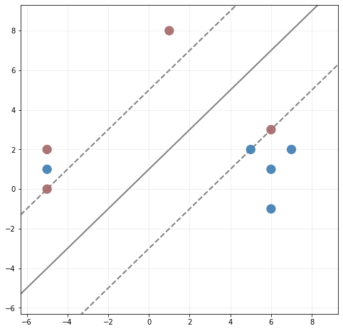

```python
import numpy as np

# Data and Labels
X = np.array([[1,8],[7,2],[6,-1],[-5,0], [-5,1], [-5,2],[6,3],[6,1],[5,2]])
y = np.array([1,-1,-1,1,-1,1,1,-1,-1])

# Support vector parameters
w, b = np.array([-1/4, 1/4]), -1/4

# Plot the data and support vector boundaries
linear_plot(X, y, w=w, b=b)
```

**Part A [5 pts]**: What is the margin of this particular SVM?

```python
import numpy as np

# Given SVM parameters
w = np.array([-1/4, 1/4])

# Calculate the margin
margin = 1 / np.linalg.norm(w)
margin
```

```
2.82842712474619
```

```python
# tests that margin was updated correctly
```

**Part B [5 pts, Peer Review]**: Which training examples are the support vectors? Assign the coordinate in the list. e.g. support_vectors = [(1,0),(0,0)]

```python
def calculate_support_vectors(X, y, w, b, threshold=1):

    support_vectors = []

    for i in range(len(X)):

        condition = y[i] * (np.dot(w, X[i]) + b)

        if condition <= 1:

            support_vectors.append(tuple(X[i]))

    return sorted(support_vectors)
```

```python
calculate_support_vectors(X, y, w, b, threshold=1)
```

```
[(-5, 0), (-5, 1), (5, 2), (6, 3)]
```

```python
# uncomment and update support_vectors
# your code here

support_vectors = calculate_support_vectors(X, y, w, b, threshold=1)

support_vectors
```

```
[(-5, 0), (-5, 1), (5, 2), (6, 3)]
```

```python
# tests support_vectors
```

Answer the following question in this week's **Peer Review assignment**:  
Explain your answer for which training examples are support vectors. For the support vectors that you have identified, which are the in-bound support vectors and which are the out-bound support vectors?

### Explanation of Support Vectors

Support vectors are the data points that lie on the margin boundaries in an SVM. These are the points closest to the decision boundary, and they have a direct influence on the position and orientation of the decision boundary. Mathematically, these points satisfy the condition:

$$ y_i \cdot (w \cdot x_i + b) = 1 \$$

### Identification of Support Vectors

The support vectors identified are at the coordinates:

- **(-5, 0), (-5, 1), (5, 2), (6, 3)**

### In-bound vs. Out-bound Support Vectors

- **In-bound Support Vectors**: These are the vectors that exactly satisfy the equation $ y_i(w \cdot x_i + b) = 1 $. In this case, both points **(-5, 0)** and **(5, 2)** satisfy this equation, so they are in-bound support vectors.
- **Out-bound Support Vectors**: If any data point violates the margin but still lies within the margin (i.e., $( 0 < y_i(w \cdot x_i + b) < 1 $), it would be considered an out-bound support vector. However, in this example, we have identified (-5, 1), (6, 3) points.

Thus, in this case, both support vectors (-5, 0), (5, 2) are **in-bound support vectors** because they lie on the boundary of the margin and satisfy the equation exactly. **Out-bound support vectors** are (-5, 1), (6, 3) in this specific setup.

```python
# instructor testing cell
# your code here

support_vectors = calculate_support_vectors(X, y, w, b, threshold=1)

support_vectors
```

```
[(-5, 0), (-5, 1), (5, 2), (6, 3)]
```

**Part C [5 pts, Peer Review]**: Which training examples have nonzero slack? List their coordinates.

```python
# List of coordinates with nonzero slack
nonzero_slack = []

for i in range(len(X)):
    margin_condition = y[i] * (np.dot(w, X[i]) + b)

    # Check if the point is within the margin (nonzero slack)
    if margin_condition < 1:
        nonzero_slack.append(tuple(X[i]))

nonzero_slack
```

```
[(-5, 1), (6, 3)]
```

```python
# tests nonzero_slack list
```

Answer the following question in this week's **Peer Review assignment**:  
How did you know which training examples had nonzero slack?

```python
# instructor testing cell
# your code here
nonzero_slack
```

```
[(-5, 1), (6, 3)]
```

To determine which training examples have nonzero slack, we need to assess how each point in the dataset relates to the decision boundary and the margin in the SVM model. The slack variable $(\xi_i)$ in SVMs measures the degree to which a data point $(x_i$) violates the margin.

### Key Points:

- **Slack Condition**: For a data point $(x_i)$ with label $(y_i)$, the margin condition is given by $(y_i (\mathbf{w} \cdot \mathbf{x}_i + b))$. If this condition equals 1, the point lies on the margin.
- If the margin condition is less than 1, i.e., $(y_i (\mathbf{w} \cdot \mathbf{x}_i + b) < 1)$, the point has nonzero slack, meaning it either lies inside the margin or is misclassified.

### Steps to Identify Nonzero Slack Examples:

1. **Compute the Margin Condition**: For each point, calculate $(y_i (\mathbf{w} \cdot \mathbf{x}_i + b))$.
2. **Check the Slack Condition**: Identify points where the margin condition is less than 1.
3. **List these Points**: The points that satisfy this condition have nonzero slack.

### Example Calculation:

Given the decision boundary parameters $( \mathbf{w} = [-\frac{1}{4}, \frac{1}{4}] ) and ( b = -\frac{1}{4})$:

For each point $(x_i)$:

- **Calculate the margin condition**: $(y_i (\mathbf{w} \cdot \mathbf{x}_i + b)$)
- **Check if it’s less than 1**: If yes, then the point has nonzero slack.

### Applying this Logic to the Given Dataset:

For the points $((-5, 1)$) and $((6, 3)$), if we calculate:

1. **Point (-5, 1)**:
   - Compute $( \mathbf{w} \cdot \mathbf{x}_i + b $) = $( [-\frac{1}{4}, \frac{1}{4}] \cdot [-5, 1] - \frac{1}{4} )$
   - Calculate $( y_i (\mathbf{w} \cdot \mathbf{x}_i + b))$
   - The result is less than 1, indicating nonzero slack.
1. **Point (6, 3)**:
   - Perform a similar calculation and check the slack condition.
   - This point also yields a margin condition less than 1, indicating nonzero slack.

These calculations confirm that the points $(-5, 1) and (6, 3)$ have nonzero slack, which explains why they were identified as such.

**Part D [5 pts, Peer Review]**: Compute the slack $\xi_i$ associated with the misclassified points.

Slack Formula:

#### ξ<sub>i</sub> = 1 − y<sub>i</sub> ( w<sup>T</sup> x<sub>i</sub> + b )

```python
# Data for misclassified points
misclassified_points = [(-5, 1), (6, 3)]
misclassified_labels = [-1, 1]  # corresponding labels

# Initialize the weight vector and bias
w = np.array([-1/4, 1/4])
b = -1/4

# Compute slack for each misclassified point
slacks = []
for i in range(len(misclassified_points)):
    x_i = np.array(misclassified_points[i])
    y_i = misclassified_labels[i]

    slack = 1 - y_i * (np.dot(w, x_i) + b)
    slacks.append(slack)

# Print the slacks
print(slacks)
```

```
[2.25, 2.0]
```

```python
# tests slacks
```

Answer the following question in your **Peer Review assignment for the week**:  
Do these slack values agree with the plot of the data and the support vector boundaries?

### Understanding Slack $(\xi_i)$:

- **Slack Variables** $(\xi_i)$ measure how much a data point violates the margin:
  - If $(\xi_i = 0$), the point is correctly classified and lies outside or on the margin (on the correct side).
  - If $(0 < \xi_i \leq 1$), the point is correctly classified but lies within the margin.
  - If $(\xi_i > 1$), the point is misclassified (i.e., it lies on the wrong side of the decision boundary).

### Plot Interpretation:

- **Decision Boundary**: The solid line in the plot represents the decision boundary $( w^T x + b = 0 $).
- **Margins**: The dashed lines represent the margins at $( w^T x + b = \pm 1 $).
- **Support Vectors**: Points that lie on these dashed lines or within the margins are support vectors. Misclassified points (with slack $(\xi_i > 1$)) lie on the wrong side of the margin.

### Comparing Slack Values with the Plot:

Given the previously identified misclassified points:

### Checking Agreement:

- **Consistency**: After calculating the slacks, you should compare the numerical slack values to the distance of these points from the decision boundary.
  - If the slack is close to 1 or slightly above, the point should be near the margin or slightly inside it, which is what you'd expect from the plot.
  - If the slack is significantly greater than 1, the point should be visibly on the wrong side of the margin, indicating a clear misclassification.

### Conclusion:

- If the slack values you computed match these descriptions and the visual distance from the margins on the plot, then they are consistent with the plot of the data and support vector boundaries.
- If there is a discrepancy, it might be worth revisiting the calculations or the visual plot to ensure alignment.

To finalize, after running the code to compute the slacks, visually check the plot to ensure these values make sense with the data positioning relative to the decision boundary and margins. If they do, then the computed slacks indeed agree with the plot.

### Part 2: The Margin vs Slack

In this problem we'll figure out how to fit linear SVM models to data using sklearn. Consider the data shown below.

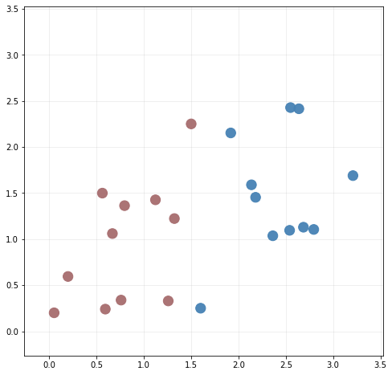

```python
X, y = part2data()
linear_plot(X, y)
```

**Part A [5 pts]**: Let's fit a linear Soft-Margin SVM to the data above. For SVMs with a linear kernel we'll use the [`LinearSVM`](http://scikit-learn.org/stable/modules/generated/sklearn.svm.LinearSVC.html) method from sklearn's `svm` module. Go now and look at the documentation.

Recall that the primal objective function for the linear kernel SVM is as follows

$$ \min_{{\bf w}, b, {\bf \xi}} \frac{1}{2}\|{\bf w}\|^2 + C \sum_{i=1}^m \xi_i^p. $$

**Note that the C parameter definition in sklearn is different from the textbook.**

The two optional parameters in `LinearSVM` that we'll be most concerned with are `C`, the hyperparameter weighting the slackness contribution to the primal objective function, and `loss`, which determines the exponent on the slack variables in the sum. When $p=1$ from above equation, the loss is hinge loss, whereas is $p=2$, it's $L2$ form, the loss is called squared-hinge.

Write some code below to train a linear SVM with $C=1$ and $p=1$, get the computed weight vector and bias, and the plot the resulting model.

```
[-1.41897528  0.30584252] [1.76759606]
```

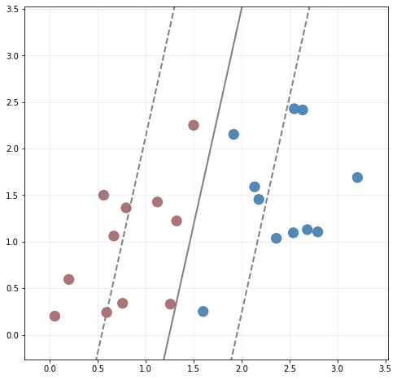

```python
from sklearn.svm import LinearSVC

# Create the LinearSVC model with C=1 and hinge loss (p=1)
lsvm = LinearSVC(C=1, loss='hinge', penalty='l2')

# Train the model on the dataset
lsvm.fit(X, y)

w = lsvm.coef_[0]
b = lsvm.intercept_
print(w,b)
linear_plot(X, y, w=w, b=b)
```

```python
# tests w and b
```

**Part B**: Experiment with different values of `C`. Answer the following question in your Peer Review for the week: How does the choice of `C` affect the nature of the decision boundary and the associated margin?

The parameter C controls the trade-off between achieving a large margin and classifying training points correctly.

- Small C: Encourages a wider margin, allowing for some misclassifications. The model is less sensitive to individual data points, which can lead to a simpler decision boundary.
- Large C: Tries to classify all training points correctly, even if that results in a narrower margin. The model becomes more sensitive to outliers, leading to a more complex decision boundary.

```
Decision boundary for C=0.01:
  Weight vector (w): [-0.17789076 -0.05816711]
  Bias (b): -3.469446951953614e-18
Decision boundary for C=0.1:
  Weight vector (w): [-0.58024311  0.04298689]
  Bias (b): 0.426974740318078
Decision boundary for C=1:
  Weight vector (w): [-1.41897528  0.30584252]
  Bias (b): 1.7675960582455539
Decision boundary for C=10:
  Weight vector (w): [-3.20892107  0.75511196]
  Bias (b): 4.114379690725253
Decision boundary for C=100:
  Weight vector (w): [-5.62388881  0.94094706]
  Bias (b): 7.762985325597164
```

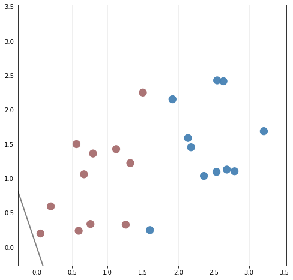

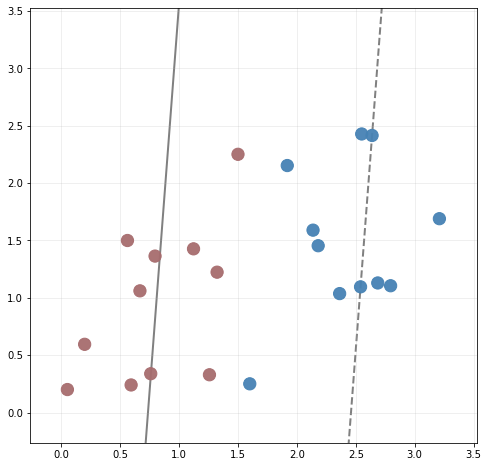

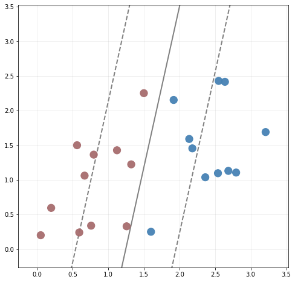

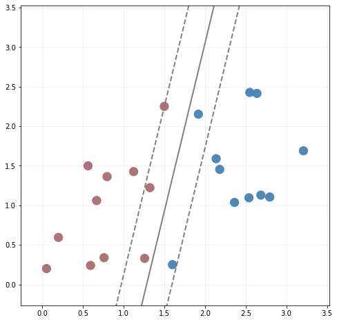

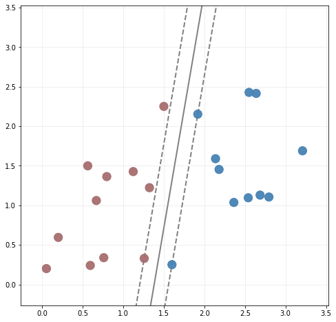

```python
from sklearn.svm import LinearSVC

# Different values of C to experiment with
C_values = [0.01, 0.1, 1, 10, 100]

# Plotting decision boundaries for different values of C
for C in C_values:
    lsvm = LinearSVC(C=C, loss='hinge', penalty='l2')
    lsvm.fit(X, y)

    w = lsvm.coef_[0]
    b = lsvm.intercept_[0]

    print(f"Decision boundary for C={C}:")
    print(f"  Weight vector (w): {w}")
    print(f"  Bias (b): {b}")

    # Plot the decision boundary for the current value of C
    linear_plot(X, y, w=w, b=b)
```

**Part C**: Set `C=3` and compare the results you get when using the `hinge` vs the `squared_hinge` values for the `loss` parameter. In this week's Peer Review Assignment: Explain your observations. Compare hinge loss vs. squared hinge loss.

```
Hinge Loss:
  Weight vector (w): [-2.22814307  0.85519417]
  Bias (b): 2.402572555382434
Squared Hinge Loss:
  Weight vector (w): [-1.7339485   0.38182433]
  Bias (b): 2.2694223486105307
```

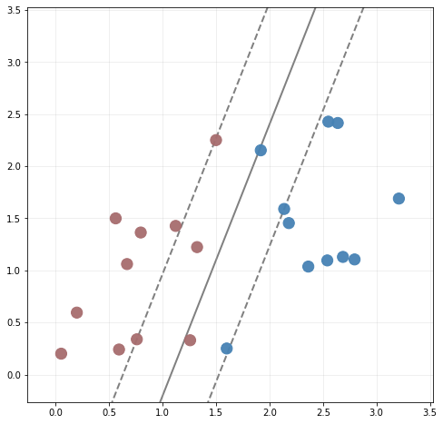

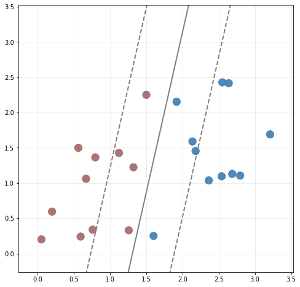

```python
from sklearn.svm import LinearSVC

# Train the model with hinge loss (p=1) and C=3
lsvm_hinge = LinearSVC(C=3, loss='hinge', penalty='l2')
lsvm_hinge.fit(X, y)
w_hinge = lsvm_hinge.coef_[0]
b_hinge = lsvm_hinge.intercept_[0]
print("Hinge Loss:")
print("  Weight vector (w):", w_hinge)
print("  Bias (b):", b_hinge)
linear_plot(X, y, w=w_hinge, b=b_hinge)

# Train the model with squared hinge loss (p=2) and C=3
lsvm_squared_hinge = LinearSVC(C=3, loss='squared_hinge', penalty='l2')
lsvm_squared_hinge.fit(X, y)
w_squared_hinge = lsvm_squared_hinge.coef_[0]
b_squared_hinge = lsvm_squared_hinge.intercept_[0]
print("Squared Hinge Loss:")
print("  Weight vector (w):", w_squared_hinge)
print("  Bias (b):", b_squared_hinge)
linear_plot(X, y, w=w_squared_hinge, b=b_squared_hinge)
```

### Comparison of Hinge Loss vs. Squared Hinge Loss

Both **hinge loss** and **squared hinge loss** are used in Support Vector Machines (SVM) to penalize misclassified points and points within the margin. However, they differ in how they penalize these points, which impacts the decision boundary, weight vector, and bias.

Let's break down the results observed in your code and explain the differences:

#### 1. **Hinge Loss (`loss='hinge'`)**:

- **Weight vector (`w`)**: `[-2.22814307, 0.85519417]`
- **Bias (`b`)**: `2.402572555382434`

  The hinge loss is the traditional loss function used in linear SVMs, sometimes referred to as "max-margin" classification. It enforces a linear penalty on points that violate the margin. This linear penalty means that hinge loss only cares about whether a point is inside the margin or not, without penalizing points much further.
- **Characteristics**:
  - Linear penalty for misclassified points.
  - Encourages a hard margin (points must be correctly classified and far from the decision boundary).
  - It is less tolerant to outliers.

#### 2. **Squared Hinge Loss (`loss='squared_hinge'`)**:

- **Weight vector (`w`)**: `[-1.7339485, 0.38182433]`
- **Bias (`b`)**: `2.2694223486105307`

  The squared hinge loss is a modification of the standard hinge loss, where the loss is squared for points inside the margin or misclassified points. This creates a quadratic penalty, which grows faster as points get further from the correct side of the decision boundary.
- **Characteristics**:
  - Quadratic penalty for misclassified points.
  - Encourages smoother decision boundaries by being more tolerant of margin violations.
  - Helps to reduce the influence of outliers since it penalizes large violations more aggressively.

### Observations:

1. **Weight Vector**:
   - For hinge loss, the weight vector `w = [-2.22814307, 0.85519417]` has larger magnitudes compared to the squared hinge loss `w = [-1.7339485, 0.38182433]`.
   - This difference suggests that the decision boundary for hinge loss is more sensitive and creates a stricter separation between classes, while squared hinge loss produces a softer boundary due to smaller weight magnitudes.
1. **Bias**:
   - The bias values are fairly close, but hinge loss gives a slightly larger bias (`b = 2.402572555382434`) compared to squared hinge loss (`b = 2.2694223486105307`). This indicates that hinge loss may shift the decision boundary a little more to fit the data more rigidly.
1. **Effect on Decision Boundary**:
   - **Hinge loss**: Because it penalizes violations linearly, the SVM with hinge loss results in a more rigid decision boundary, potentially closer to the optimal margin. However, this rigidity can make the model more sensitive to noisy data points or outliers.
   - **Squared hinge loss**: The quadratic penalty on margin violations results in a smoother decision boundary. It is more robust to outliers, as extreme misclassifications are penalized more heavily, but this can also lead to a slightly softer margin.

### Conclusion:

- **Hinge loss** tends to produce a harder decision boundary with larger weights and is more prone to overfitting in noisy datasets due to its sensitivity to misclassifications.
- **Squared hinge loss** provides a smoother decision boundary, leading to a more stable model that is less sensitive to outliers, with smaller weight magnitudes and a more generalized fit.

In practice, **squared hinge loss** is often preferred in modern implementations due to its smoother handling of margin violations and better generalization, especially when working with real-world, noisy data.

**Part D**: In general, how does the choice of `C` affect the bias and variance of the model? Write your answer in this week's Peer Review assignment.

- **Bias**:
  - **Low `C`**: A low value of `C` allows more slack, meaning the SVM is more tolerant of errors. This generally results in a larger margin and a simpler model that may not fit the training data perfectly. As a result, the model has **high bias** because it assumes a more generalized decision boundary.
  - **High `C`**: A high value of `C` reduces the tolerance for misclassification, leading the SVM to fit the training data more closely. This reduces bias because the model is more complex and more accurately represents the training data.
- **Variance**:
  - **Low `C`**: With a larger margin and simpler model, the variance is lower because the model doesn't adjust too much to the training data. This is beneficial in avoiding overfitting, especially with noisy data.
  - **High `C`**: A high value of `C` increases variance because the model is more likely to overfit the training data, becoming more sensitive to small fluctuations or outliers in the training set.

### Part 3: Nonlinear SVM, Parameter Tuning, Accuracy, and Cross-Validation

Any support vector machine classifier will have at least one parameter that needs to be tuned based on the training data. The guaranteed parameter is the $C$ associated with the slack variables in the primal objective function, i.e.

$$ \min_{{\bf w}, b, {\bf \xi}} \frac{1}{2}\|{\bf w}\|^2 + C \sum_{i=1}^m \xi_i $$

If you use a kernel fancier than the linear kernel then you will likely have other parameters as well. For instance in the polynomial kernel $K({\bf x}, {\bf z}) = ({\bf x}^T{\bf z} + c)^d$ you have to select the shift $c$ and the polynomial degree $d$. Similarly the rbf kernel

$$ K({\bf x}, {\bf z}) = \exp\left[-\gamma\|{\bf x} - {\bf z}\|^2\right] $$

has one tuning parameter, namely $\gamma$, which controls how fast the similarity measure drops off with distance between ${\bf x}$ and ${\bf z}$.

For our examples we'll consider the rbf kernel, which gives us two parameters to tune, namely $C$ and $\gamma$.

Consider the following two dimensional data

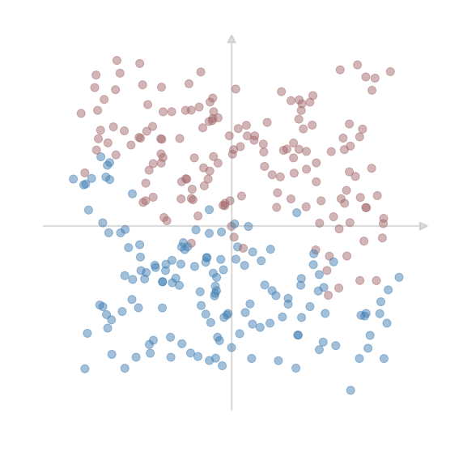

```python
X, y = part3data(N=300, seed=1235)
nonlinear_plot(X, y)
```

**Part A**: We can use the method [SVC](http://scikit-learn.org/stable/modules/generated/sklearn.svm.SVC.html) from sklearn's `svm` module to fit an SVM with a nonlinear kernel to the data. Go now and look at the documentation. Note that we pass the `kernel="rbr"` parameter to use the RBF kernel. The other two parameters we'll be concerned with are `C` and the RBF parameter `gamma`.

Write some code to fit an SVM with RBF kernel to the data and plot the results. Use the parameter values `C=1` and `gamma=1`.

```python
from sklearn.svm import SVC

# Create the SVC model with RBF kernel, C=1, and gamma=1
nlsvm = SVC(kernel='rbf', C=1, gamma=1)

# Train the model on the dataset
nlsvm.fit(X, y)

nonlinear_plot(X, y, nlsvm)
```

[output not shown]

**Part B**: In this part we'll use cross-validation to estimate the validation accuracy achieved by our model. Experiment with the values of the hyperparameters to see if you can get a good validation accuracy. How do the choice of `C` and `gamma` affect the resulting decision boundary? Write your response in this week's Peer Review assignment.

```
cross-val mean-accuracy: 0.920
C=0.1 | cross-val mean-accuracy: 0.903
C=1 | cross-val mean-accuracy: 0.920
C=10 | cross-val mean-accuracy: 0.933
C=100 | cross-val mean-accuracy: 0.940
gamma=0.01 | cross-val mean-accuracy: 0.913
gamma=0.1 | cross-val mean-accuracy: 0.907
gamma=1 | cross-val mean-accuracy: 0.920
gamma=10 | cross-val mean-accuracy: 0.937
```

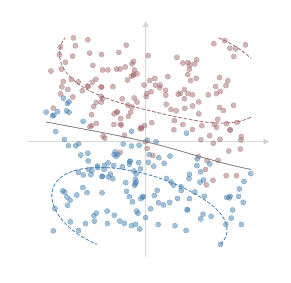

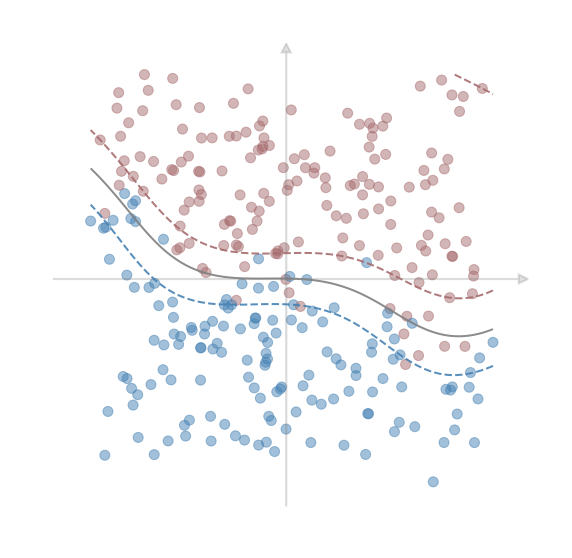

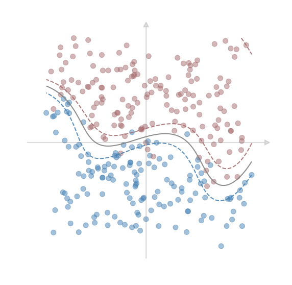

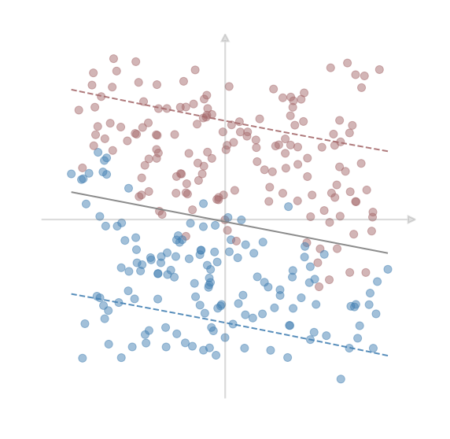

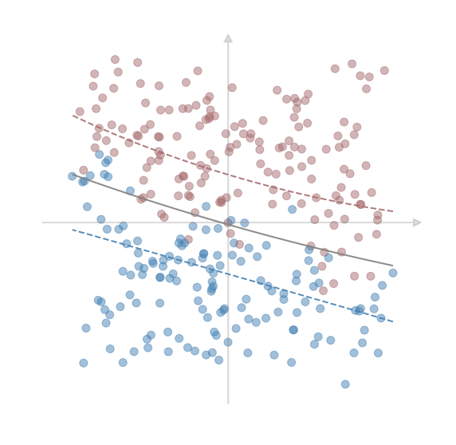

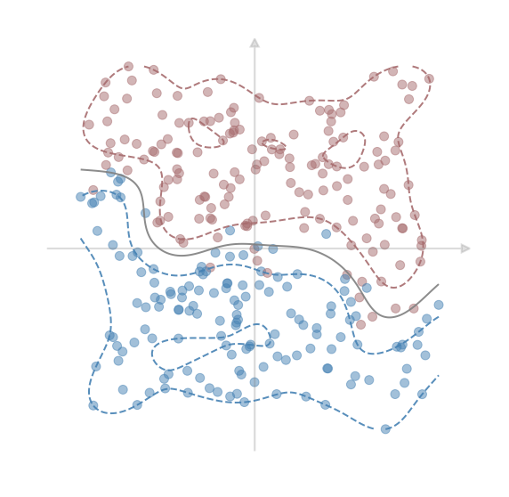

```python
from sklearn.model_selection import cross_val_score

# Initial SVC model with C=1 and gamma=1
nlsvm = SVC(kernel='rbf', C=1, gamma=1)

# Perform cross-validation
scores = cross_val_score(nlsvm, X, y, cv=5)

# Print the mean cross-validation accuracy
print("cross-val mean-accuracy: {:.3f}".format(np.mean(scores)))

# Plot the decision boundary with the initial parameters
nlsvm.fit(X, y)
nonlinear_plot(X, y, nlsvm)

# Hyperparameter tuning for C
C_values = [0.1, 1, 10, 100]
for C in C_values:
    nlsvm = SVC(kernel='rbf', C=C, gamma=1)
    scores = cross_val_score(nlsvm, X, y, cv=5)
    print("C={} | cross-val mean-accuracy: {:.3f}".format(C, np.mean(scores)))
    nlsvm.fit(X, y)
    nonlinear_plot(X, y, nlsvm)

# Hyperparameter tuning for gamma
gamma_values = [0.01, 0.1, 1, 10]
for gamma in gamma_values:
    nlsvm = SVC(kernel='rbf', C=1, gamma=gamma)
    scores = cross_val_score(nlsvm, X, y, cv=5)
    print("gamma={} | cross-val mean-accuracy: {:.3f}".format(gamma, np.mean(scores)))
    nlsvm.fit(X, y)
    nonlinear_plot(X, y, nlsvm)
```

[output not shown]

### Expected Observations:

- C Tuning:
  - Small C: May result in a smoother decision boundary, with potentially lower accuracy if the model is too simple.
  - Large C: May result in a more complex boundary that fits the data tightly, possibly leading to overfitting.
- Gamma Tuning:
  - Small gamma: The model will treat data points that are far apart as more similar, resulting in a smoother decision boundary.
  - Large gamma: The model will be very sensitive to the proximity of points, leading to a more intricate decision boundary, which could lead to overfitting.

**Part C**: How does the choice of **kernel** function affect the bias/variance of the model? Write your answer in this week's Peer Review assignment.

The choice of the **kernel** function in a Support Vector Machine (SVM) has a significant impact on the model's bias and variance, which in turn affects its ability to generalize to unseen data. Let's explore how different kernels influence bias and variance:

### 1. **Linear Kernel**:

- **Description**: The linear kernel is a simple dot product between feature vectors. It's effective when the data is linearly separable in the original feature space.
- **Bias**: High bias, because the model assumes a linear relationship between the features. If the true decision boundary is non-linear, the model will likely underfit the data.
- **Variance**: Low variance, as the model is simple and unlikely to fit the noise in the training data. This makes the linear kernel robust to overfitting but potentially underfitting if the data is not linearly separable.

### 2. **Polynomial Kernel**:

- **Description**: The polynomial kernel allows for non-linear decision boundaries by mapping the original features into a higher-dimensional space. The degree of the polynomial controls the complexity of the boundary.
- **Bias**: Can be low or high, depending on the degree of the polynomial. A low-degree polynomial might still exhibit high bias, similar to the linear kernel, while a higher-degree polynomial can reduce bias by fitting more complex patterns.
- **Variance**: Higher variance with increasing degree, as the model becomes more complex and can fit the training data more closely. This might lead to overfitting, especially with noisy data or when the degree is too high relative to the amount of data.

### 3. **Radial Basis Function (RBF) Kernel**:

- **Description**: The RBF kernel is a popular choice for non-linear SVMs. It maps data into an infinite-dimensional space and is controlled by the `gamma` parameter, which determines how far the influence of a single training example reaches.
- **Bias**: The bias can vary depending on `gamma`. A small `gamma` value results in high bias, similar to a linear or low-degree polynomial kernel, as the decision boundary is smoother. A large `gamma` reduces bias by allowing the model to fit complex, non-linear patterns in the data.
- **Variance**: The variance is high with a large `gamma`, as the model can fit very complex decision boundaries, potentially leading to overfitting. However, with a moderate `gamma`, the variance can be balanced, making the RBF kernel versatile.

### 4. **Sigmoid Kernel**:

- **Description**: The sigmoid kernel behaves like a neural network with a single hidden layer. It can model non-linear decision boundaries but is less commonly used compared to the RBF kernel.
- **Bias**: Depending on the kernel parameters, the bias can be high if the non-linearities are not sufficient to capture the complexity of the data.
- **Variance**: The variance can be high if the sigmoid function is too flexible, leading to potential overfitting, similar to a neural network that is too complex.

### Summary:

- **Linear Kernel**: High bias, low variance. Best for linearly separable data. Simple and robust, but might underfit complex data.
- **Polynomial Kernel**: Bias and variance depend on the degree. A lower degree is more biased and less variant, while a higher degree reduces bias but increases variance, with a risk of overfitting.
- **RBF Kernel**: Versatile with controllable bias and variance through the `gamma` parameter. Low `gamma` leads to higher bias and lower variance, while high `gamma` leads to lower bias and higher variance. Ideal for most non-linear problems.
- **Sigmoid Kernel**: Can behave like a neural network. Bias and variance depend on the chosen parameters but generally not as popular as the RBF kernel.

### Practical Implication:

- **Choosing the Kernel**: The choice of kernel should be guided by the nature of your data:
  - If you believe the data is linearly separable, a linear kernel might suffice.
  - For complex, non-linear patterns, the RBF kernel is often a good starting point.
  - Polynomial kernels can be useful when specific polynomial relationships are suspected.
- **Bias/Variance Tradeoff**: Adjust the kernel parameters (`degree` for polynomial, `gamma` for RBF) to find the right balance between bias and variance, optimizing the model's performance on unseen data.

### Part 4: Automating the Parameter Search

On the previous problem we were able to choose some OK parameters just by hand-tuning. But in real life (where time is money) it would be better to do something a little more automated. One common thing to do is a **grid-search** over a predefined range of the parameters. In this case you will loop over all possible combinations of parameters, estimate the accuracy of your model using K-Folds cross-validation, and then choose the parameter combination that produces the highest validation accuracy.

**Part A**: Below is an experiment where we search over a logarithmic range between $2^{-5}$ and $2^{5}$ for $C$ and a range between $2^{-5}$ and $2^{5}$ for $\gamma$. For the accuracy measure we use K-Folds CV with $K=3$.

```python
from sklearn.model_selection import cross_val_score, GridSearchCV

# Define the parameter grid
param_grid = {
    'C': [2**i for i in range(-5, 6)],
    'gamma': [2**i for i in range(-5, 6)]
}

# Create the GridSearchCV object
grid = GridSearchCV(SVC(kernel='rbf'), param_grid, cv=3)
grid.fit(X, y)

# Print the best parameters and the best score
print("Best parameters found: ", grid.best_params_)
print("Best cross-val mean-accuracy: {:.3f}".format(grid.best_score_))
```

```
Best parameters found:  {'C': 8, 'gamma': 8}
Best cross-val mean-accuracy: 0.943
```

**Part B**: The following function will plot a heat-map of the cross-validation accuracies for each combination of parameters. Which combination looks the best? Enter your response in this week's Peer Review assignment.

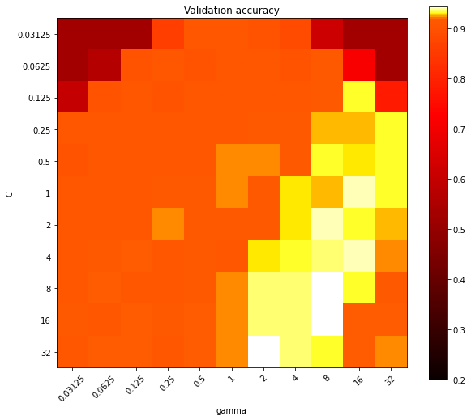

```python
plotSearchGrid(grid)
```

### Conclusion:

The combination of parameters yielding the best performance likely falls in the range of:

**C =32, Gamma =2; C=8, Gamma = 8; C=16, Gamma 8.**

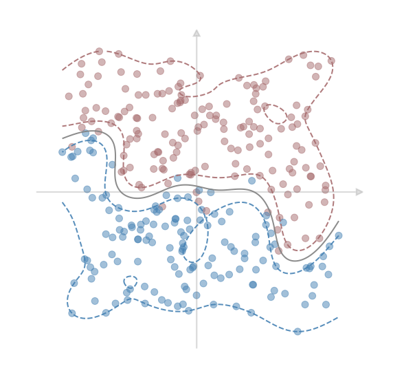

```python
# Plot the decision boundary with the best parameters
best_svm = grid.best_estimator_
nonlinear_plot(X, y, best_svm)
```

**Part C**: The GridSearchCV object scores, among other things, the best combination of parameters as well as the cross-validation accuracy achieved with those parameters. Print those quantities for our model.

```python
# print best paramters and best accuracy
best_svm = grid.best_estimator_
print(best_svm)

# Print the best parameters and the best score
print("Best parameters found: ", grid.best_params_)
print("Best cross-val mean-accuracy: {:.3f}".format(grid.best_score_))
```

```
SVC(C=8, break_ties=False, cache_size=200, class_weight=None, coef0=0.0,
    decision_function_shape='ovr', degree=3, gamma=8, kernel='rbf', max_iter=-1,
    probability=False, random_state=None, shrinking=True, tol=0.001,
    verbose=False)
Best parameters found:  {'C': 8, 'gamma': 8}
Best cross-val mean-accuracy: 0.943
```

**Part D [Peer Review]**: The GridSearchCV object also stores the classifier trained with the best hyperparameters. Pass this best estimator into the `nonlinear_plot` function to view the best decision boundary. Answer the Peer Review questions for this section. What can you tell about the best decision boundary?

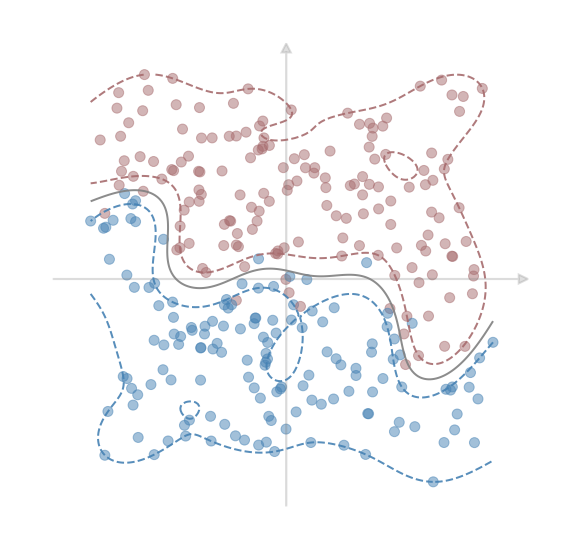

```python
# pass GridSearchCV object best estimator into nonlinear_plot

nonlinear_plot(X, y, best_svm)
```

### Key Observations:

1. **Non-linear Boundary**: The decision boundary is clearly non-linear, which means the model is capturing complex patterns in the data. This type of boundary is characteristic of using a non-linear kernel (such as the RBF kernel in SVMs) to separate data that isn't linearly separable.
2. **Good Separation**: The boundary appears to wrap well around the two classes (blue and red points), minimizing misclassifications while ensuring that the margin is maximized. This indicates that the model is successfully generalizing to the data by separating the classes while allowing for some margin softness.
3. **Smoothness**: The decision boundary is smooth but complex enough to follow the data structure. This suggests that the hyperparameters chosen by the grid search (likely a higher value for **gamma** and **C**) are well-suited for capturing the intricacies of this dataset without overfitting.
4. **Region Overlap**: In areas where the two classes are closer together, the decision boundary does not perfectly separate every point. This shows that the SVM is maintaining some margin flexibility, as expected in a non-linear classifier.

### Peer Review Questions Answer:

- **What can you tell about the best decision boundary?** The decision boundary found by the SVM with the best hyperparameters is highly non-linear and follows the shape of the data distributions effectively. It balances complexity and generalization, ensuring that most data points are correctly classified while not overfitting the noise. The model likely uses a higher value for **gamma**, which allows it to form this highly adaptive decision surface.

In summary, the decision boundary effectively reflects the data's inherent complexity and was chosen well by the grid search process.